# Overview

### Accessing model fits & estimated locations

Summary information about the fit can be obtained via the `summary` function:

```r
summary(fit)
```

```
#>  Animal id Model Time n.obs n.filt n.fit n.pred n.rr converged   AICc
#>      54591    rw   24    64      6    58    113    .      TRUE 1350.5
#>
#> --------------
#> 54591
#> --------------
#>  Parameter Estimate Std.Err
#>      rho_p  -0.8551  0.0374
#>    sigma_x   4.5703  0.4356
#>    sigma_y   3.9675  0.3779
```

The summary table lists information about the fit, including the number of observations in the input data (`n.obs`), the number of observation flagged to be ignored by the SSM (`n.filt`), the number of fitted location estimates (`n.fit`), the number of predicted location estimates (`n.pred`), the number of rerouted location estimates (if present, `n.rr`), model convergence status, and AICc. When fitting to multiple individuals, these statistics are repeated on separate lines for each individual. Separate tables of SSM parameter estimates and their SE’s are also printed for each individual. The parameter estimates displayed vary depending on the SSM process model selected by the user (`rw`, `crw`, or `mp`) and the automatically chosen measurement model(s). Here, `sigma_x` and `sigma_y` are the process error standard deviations in the x and y directions, `rho_p` is the correlation parameter in the covariance term. The `Std. Error` column lists the standard errors, calculated via the Delta method (see TMB documentation for details), for each estimated parameter.

`fit_ssm` usually returns two sets of estimated locations in the model fit object: fitted values and predicted values. The fitted values occur at the times of the observations (that passed the prefilter step) to which the SSM was fit. The predicted values occur at the regular time intervals specified by the `time.step` argument. If `time.step = NA`, then no predicted values are estimated or returned in the model fit object.

Users can obtain the fitted or predicted locations as a data.frame by using `grab()`:

```r
## grab fitted locations
floc <- grab(fit, what = "fitted")
floc[1:3,]
```

```
#> # A tibble: 3 × 8
#>   id    date                  lon   lat      x      y  x.se  y.se
#>   <chr> <dttm>              <dbl> <dbl>  <dbl>  <dbl> <dbl> <dbl>
#> 1 54591 2012-03-05 05:09:33  111. -66.4 12309. -9956.  1.18 1.30
#> 2 54591 2012-03-06 04:55:14  110. -66.4 12287. -9947. 28.5  0.276
#> 3 54591 2012-03-09 04:27:49  110. -66.5 12299. -9972.  8.88 1.41
```

```r
## grab predicted locations in projected form
ploc <- grab(fit, what = "predicted", as_sf = TRUE)
ploc[1:3,]
```

```
#> Simple feature collection with 3 features and 4 fields
#> Geometry type: POINT
#> Dimension:     XY
#> Bounding box:  xmin: 12286.57 ymin: -9955.649 xmax: 12308.66 ymax: -9946.821
#> CRS:           +proj=merc +lon_0=0 +datum=WGS84 +units=km +no_defs
#>      id                date      x.se       y.se                   geometry
#> 1 54591 2012-03-05 05:00:00  1.381993  1.4427854 POINT (12308.66 -9955.649)
#> 2 54591 2012-03-06 05:00:00 28.529870  0.4192654 POINT (12286.57 -9946.821)
#> 3 54591 2012-03-07 05:00:00 91.268027 77.4567768 POINT (12290.69 -9955.401)
```

Here, the fitted location data.frame includes individual id, date-time, longitude, latitude, x and y (typically from the default World Mercator projection) and their standard errors (in km). The predicted location data.frame is an `sf` object with geometry and Coordinate Reference System information. This `sf` output format is useful for custom mapping or calculating derived quantities from the estimated locations.

### Quickly visualise SSM fits

A generic `plot` (see `?plot.ssm_df`) method allows a quick visual of the SSM fit to the data:

```
#> $`54591`
```

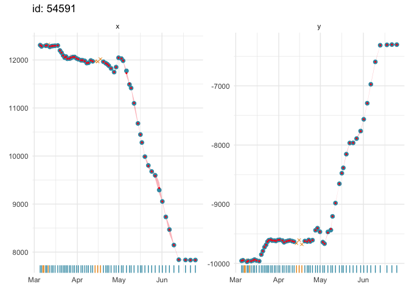

```r
# plot time-series of the fitted values
plot(fit, what = "fitted", type = 1)
```

```
#> $`54591`
```

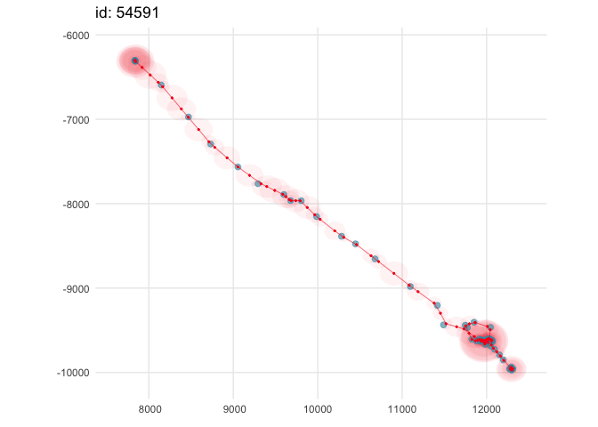

```r
# plot fitted values as a 2-d track
plot(fit, what = "predicted", type = 2, alpha = 0.05)
```

The predicted values (red points) are the state estimates predicted at regular time intervals, specified by `time.step` (here a 24 h interval). These estimates are plotted on top of 2 x SE intervals (red-filled ribbon), and the observations that passed the `prefilter` stage (blue points and blue rug at bottom). Fitted values are the state estimates corresponding to the time of each observation; their time series are plotted by default - `plot(fit)`. A 2-D time series plot of the track is invoked by the argument `type = 2`, and includes the 95 % confidence ellipses (red-filled ellipses) around the predicted locations.